# Portfolio Backtesting

Daniel P. Palomar and Rui Zhou The Hong Kong University of Science and Technology (HKUST)

2026-05-18

> This vignette illustrates the usage of the package [`portfolioBacktest`](https://CRAN.R-project.org/package=portfolioBacktest) for automated portfolio backtesting over randomized multiple datasets on a rolling-window basis, as described in Chapter 8 (Portfolio Backtesting) of (Palomar 2025). It can be used by researchers and practitioners to backtest a set of different portfolios, as well as course instructors to assess the students in their portfolio design in a fully automated and convenient manner. The results can be nicely formatted in tables and plots.

# Package Snapshot

Backtesting is a dangerous task fraught with many potential pitfalls (Luo et al. 2014; Palomar 2025). By performing a large number of randomized backtests, instead of visually inspecting a single backtest, one can obtain more realistic results.

This package backtests a list of portfolios over multiple datasets on a rolling-window basis (aka walk forward), producing final results as in the following.

- Performance table:

|  | Sharpe ratio | max drawdown | annual return | annual volatility | Sortino ratio | downside deviation | Sterling ratio | Omega ratio | VaR (0.95) | CVaR (0.95) | rebalancing period | turnover | ROT (bps) | cpu time | failure rate |
| --- | --- | --- | --- | --- | --- | --- | --- | --- | --- | --- | --- | --- | --- | --- | --- |
| Quintile | 1.09 | 0.12 | 0.19 | 0.17 | 1.57 | 0.12 | 1.69 | 1.2 | 0.02 | 0.02 | 1 | 0.03 | 237.21 | 0 | 0 |
| GMVP | 1.12 | 0.09 | 0.14 | 0.12 | 1.66 | 0.08 | 1.59 | 1.21 | 0.01 | 0.02 | 1 | 0.02 | 266.55 | 0 | 0 |
| Markowitz | 0.69 | 0.25 | 0.23 | 0.32 | 0.96 | 0.23 | 1.01 | 1.13 | 0.03 | 0.05 | 1 | 0.04 | 215.85 | 0.47 | 0 |
| 1/N | 1.17 | 0.1 | 0.17 | 0.14 | 1.73 | 0.09 | 1.61 | 1.23 | 0.01 | 0.02 | 1 | 0.01 | 755.01 | 0 | 0 |
| index | 0.94 | 0.1 | 0.13 | 0.13 | 1.35 | 0.09 | 1.32 | 1.18 | 0.01 | 0.02 | 252 | 0 |  | 0 | 0 |

- Barplot:

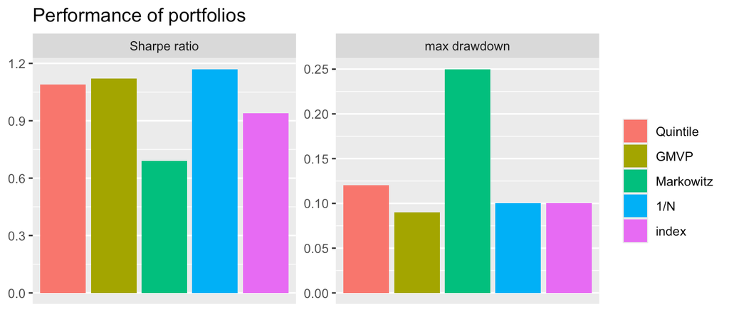

- Boxplot:

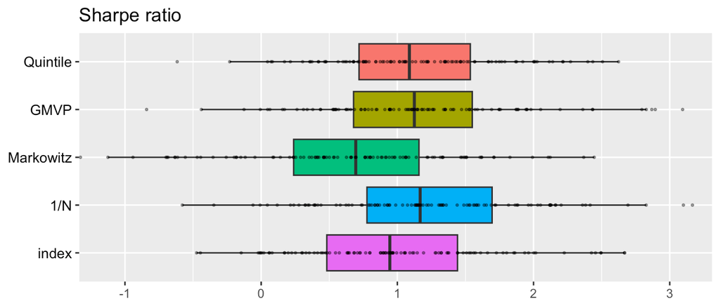

# Quick Start

Do the backtest on your own portfolio following few steps:

- **Step 1** - load package & 10 datasets

```r
library(portfolioBacktest)
data("dataset10")
```

- **Step 2** - define your own portfolio

```r
my_portfolio <- function(dataset, ...) {
  prices <- dataset$adjusted
  N <- ncol(prices)
  return(rep(1/N, N))
}
```

- **Step 3** - do backtest

```r
bt <- portfolioBacktest(my_portfolio, dataset10)
```

```
#> Backtesting 1 portfolios over 10 datasets (periodicity = daily data)...
```

- **Step 4** - check your portfolio performance (e.g., median of the 10 individual backtests)

```r
backtestSummary(bt)$performance
```

```
#>                            fun1
#> Sharpe ratio       1.476203e+00
#> max drawdown       8.937890e-02
#> annual return      1.594528e-01
#> annual volatility  1.218623e-01
#> Sortino ratio      2.057677e+00
#> downside deviation 8.351402e-02
#> Sterling ratio     2.122653e+00
#> Omega ratio        1.295090e+00
#> VaR (0.95)         1.101934e-02
#> CVaR (0.95)        1.789425e-02
#> rebalancing period 1.000000e+00
#> turnover           8.641594e-03
#> ROT (bps)          7.334458e+02
#> cpu time           1.307692e-03
#> failure rate       0.000000e+00
```

# Installation

The package can be installed from [CRAN](https://CRAN.R-project.org/package=portfolioBacktest) or [GitHub](https://github.com/dppalomar/portfolioBacktest):

```r
# install stable version from CRAN
install.packages("portfolioBacktest")

# install development version from GitHub
devtools::install_github("dppalomar/portfolioBacktest")

# Getting help
library(portfolioBacktest)
help(package = "portfolioBacktest")
?portfolioBacktest
```

# Loading Data

## Basic structure of datasets

The main function `portfolioBacktest()` requires the argument `dataset_list` to follow a certain format: it should be a list of several individual datasets, each of them being a list of several `xts` objects following exactly the same date index. One of those `xts` objects must contain the historical prices of the stocks, but we can have additional `xts` objects containing other information such as volume of the stocks or index prices. The package contains a small dataset sample for illustration purposes:

```r
data("dataset10")  # load the embedded dataset
class(dataset10)  # show dataset class
```

```
#> [1] "list"
```

```r
names(dataset10[1:3])  # show names of a few datasets
```

```
#> [1] "dataset 1" "dataset 2" "dataset 3"
```

```r
names(dataset10$`dataset 1`)  # structure of one dataset
```

```
#> [1] "adjusted" "index"
```

```r
head(dataset10$`dataset 1`$adjusted[, 1:3])
```

```
#>            MAS.Adjusted MGM.Adjusted CMI.Adjusted
#> 2015-04-24     22.05079     21.34297     121.8492
#> 2015-04-27     22.13499     21.26537     124.3041
#> 2015-04-28     22.68226     21.69223     122.5187
#> 2015-04-29     22.54755     20.47956     123.2150
#> 2015-04-30     22.30337     20.51836     123.4203
#> 2015-05-01     22.85065     20.76090     125.9823
```

Note that each dataset contains an `xts` object called `"adjusted"` (adjusted prices). By default, `portfolioBacktest()` will use such adjusted prices to calculate the portfolio return. But one can change this setting with the argument `price_name` in function `portfolioBacktest()`.

## Obtaining more data

We emphasize that 10 datasets are not enough for properly backtesting portfolios. In this package, we provide the function `stockDataDownload()` to download online data resources in the required data format. Then, the function `financialDataResample()` can help resample the downloaded data into multiple datasets (each resample is obtained by randomly choosing a subset of the stock names and randomly choosing a time period over the available long period), which can be directly passed to `portfolioBacktest()`. We recommend using these two functions to generate multiple datasets for serious backtesting:

```r
data(SP500_symbols)  # load the SP500 symbols
# download data from internet
SP500 <- stockDataDownload(stock_symbols = SP500_symbols,
                           from = "2008-12-01", to = "2018-12-01")
# resample 10 times from SP500, each with 50 stocks and 2-year consecutive data
my_dataset_list <- financialDataResample(SP500,
                                         N_sample = 50, T_sample = 252*2,
                                         num_datasets = 10)
```

Each individual dataset will contain 7 `xts` objects with names: `open`, `high`, `low`, `close`, `volume`, `adjusted`, `index`. Since the function `stockDataDownload()` may take a long time to download the data from the Internet, it will automatically save the data into a local file for subsequent fast retrieval (whenever the function is called with the same arguments). It is the responsibility of the user to download a proper universe of stocks to avoid survivorship bias.

## Expanding the datasets

Additional data can be helpful in designing portfolios. One can add as many other `xts` objects in each dataset as desired. For example, if the Moving Average Convergence Divergence (MACD) information is needed by the portfolio functions, one can manually add it to the dataset as follows:

```r
for (i in 1:length(dataset10))
  dataset10[[i]]$MACD <- apply(dataset10[[i]]$adjusted, 2,
                               function(x) { TTR::MACD(x)[ , "macd"] })
```

# Defining Portfolios

A portfolio has to be defined in the form of function that takes as input:

1. a dataset (which will be automatically windowed during the backtesting following a rolling-window basis) containing a list of `xts` objects (following the format of the elements of the argument `dataset_list`) and
2. the current portfolio `w_current` (if this argument is not used, then alternatively one can use the ellipsis `...` in the function definition).

The portfolio function has to return the portfolio as a numerical vector of normalized weights of the same length as the number of stocks.

Below we give the examples for the quintile portfolio, the global minimum variance portfolio (GMVP), and the Markowitz mean-variance portfolio (under practical constraints $\mathbf{w} \ge \mathbf{0}$ and $\mathbf{1}^{T} \mathbf{w} =1$):

```r
# define quintile portfolio
quintile_portfolio_fun <- function(dataset, w_current) {
  X <- diff(log(dataset$adjusted))[-1]  # compute log returns
  N <- ncol(X)
  # design quintile portfolio
  ranking <- sort(colMeans(X), decreasing = TRUE, index.return = TRUE)$ix
  w <- rep(0, N)
  w[ranking[1:round(N/5)]] <- 1/round(N/5)
  return(w)
}

# define GMVP (with heuristic not to allow shorting)
GMVP_portfolio_fun <- function(dataset, ...) {
  X <- diff(log(dataset$adjusted))[-1]  # compute log returns
  Sigma <- cov(X)  # compute SCM
  # design GMVP
  w <- solve(Sigma, rep(1, nrow(Sigma)))
  w <- abs(w)/sum(abs(w))
  return(w)
}

# define Markowitz mean-variance portfolio
library(CVXR)
Markowitz_portfolio_fun <- function(dataset, ...) {
  X <- diff(log(dataset$adjusted))[-1]  # compute log returns
  mu    <- colMeans(X)  # compute mean vector
  Sigma <- cov(X)       # compute the SCM
  # design mean-variance portfolio
  w <- Variable(nrow(Sigma))
  prob <- Problem(Maximize(t(mu) %*% w - 0.5*quad_form(w, Sigma)),
                  constraints = list(w >= 0, sum(w) == 1))
  result <- solve(prob)
  return(as.vector(result$getValue(w)))
}
```

The argument `w_current` can be used to control the transaction cost:

```r
Markowitz_portfolio_tc_fun <- function(dataset, w_current) {
  tau <- 0.01
  X <- diff(log(dataset$adjusted))[-1]  # compute log returns
  mu    <- colMeans(X)  # compute mean vector
  Sigma <- cov(X)       # compute the SCM
  # design mean-variance portfolio
  w <- Variable(nrow(Sigma))
  prob <- Problem(Maximize(t(mu) %*% w - 0.5*quad_form(w, Sigma) -
                             tau*sum(abs(w - w_current))),
                  constraints = list(w >= 0, sum(w) == 1))
  result <- solve(prob)
  return(as.vector(result$getValue(w)))
}
```

# Backtesting and Plotting

## Backtesting your portfolios

With the datasets and portfolios ready, we can now do the backtest easily. For example, to obtain the three portfolios’ performance over the datasets, we just need combine them in a list and run the backtest in one line:

```r
portfolios <- list("Quintile"  = quintile_portfolio_fun,
                   "GMVP"      = GMVP_portfolio_fun,
                   "Markowitz" = Markowitz_portfolio_fun)
bt <- portfolioBacktest(portfolios, dataset10, benchmark = c("1/N", "index"))
```

```
#> Backtesting 3 portfolios over 10 datasets (periodicity = daily data)...
#> Backtesting benchmarks...
```

## Result format

Here `bt` is a list storing all the backtest results according to the passed functions list (plus the two benchmarks):

```r
names(bt)
```

```
#> [1] "Quintile"  "GMVP"      "Markowitz" "1/N"       "index"
```

Each element of `bt` is also a list storing more information for each of the datasets:

```
#>                           levelName
#> 1  bt
#> 2   ¦--Quintile
#> 3   ¦   ¦--dataset 1
#> 4   ¦   ¦   ¦--performance
#> 5   ¦   ¦   ¦--cpu_time
#> 6   ¦   ¦   ¦--error
#> 7   ¦   ¦   ¦--error_message
#> 8   ¦   ¦   ¦--w_optimized
#> 9   ¦   ¦   ¦--w_rebalanced
#> 10  ¦   ¦   ¦--w_bop
#> 11  ¦   ¦   ¦--return
#> 12  ¦   ¦   ¦--wealth
#> 13  ¦   ¦   °--X_lin
#> 14  ¦   ¦--dataset 2
#> 15  ¦   ¦   ¦--performance
#> 16  ¦   ¦   ¦--cpu_time
#> 17  ¦   ¦   ¦--error
#> 18  ¦   ¦   ¦--error_message
#> 19  ¦   ¦   ¦--w_optimized
#> 20  ¦   ¦   °--... 5 nodes w/ 0 sub
#> 21  ¦   °--... 8 nodes w/ 85 sub
#> 22  °--... 4 nodes w/ 533 sub
```

One can extract any desired backtest information directly from the returned variable `bt`.

## Shaping your results

The package also contains several convenient functions to extract information from the backtest results.

- Select several performance measures of one specific portfolio:

```r
# select sharpe ratio and max drawdown performance of Quintile portfolio
backtestSelector(bt, portfolio_name = "Quintile",
                 measures = c("Sharpe ratio", "max drawdown"))
```

```
#> $performance
#>            Sharpe ratio max drawdown
#> dataset 1    1.06419447   0.09384104
#> dataset 2    1.22091716   0.10406013
#> dataset 3    2.24635921   0.06952085
#> dataset 4    1.44699083   0.09921398
#> dataset 5    0.08849001   0.17328255
#> dataset 6    0.99108926   0.10320105
#> dataset 7    1.64175055   0.08836202
#> dataset 8   -0.10916655   0.27460141
#> dataset 9    1.62468886   0.11288730
#> dataset 10   1.37221717   0.09834212
```

- Tables of several performance measures of the portfolios (classified by performance criteria):

```r
# show the portfolios performance in tables
backtestTable(bt, measures = c("Sharpe ratio", "max drawdown"))
```

```
#> $`Sharpe ratio`
#>               Quintile       GMVP    Markowitz       1/N      index
#> dataset 1   1.06419447 1.32027278  0.001373386 1.4089909 1.33623612
#> dataset 2   1.22091716 0.16541826  1.044875366 0.4355269 0.22256998
#> dataset 3   2.24635921 1.87705877  1.149650946 2.2566129 1.79107233
#> dataset 4   1.44699083 1.12233673  0.331281647 1.2145246 0.95372278
#> dataset 5   0.08849001 0.05190026  0.061763031 0.3137457 0.20553014
#> dataset 6   0.99108926 2.08192072  0.767195436 1.7823589 2.49533696
#> dataset 7   1.64175055 2.69917968 -0.251919230 2.3238009 1.58760559
#> dataset 8  -0.10916655 0.16661653  1.075091650 0.1975010 0.03506698
#> dataset 9   1.62468886 1.27456766  0.779205761 1.5434145 1.37981616
#> dataset 10  1.37221717 1.96674860  0.483356334 1.8760481 1.72522587
#>
#> $`max drawdown`
#>              Quintile       GMVP  Markowitz        1/N      index
#> dataset 1  0.09384104 0.05733409 0.20824654 0.06678369 0.05595722
#> dataset 2  0.10406013 0.13027178 0.23314406 0.13218930 0.12352525
#> dataset 3  0.06952085 0.04947330 0.16813539 0.04800769 0.05761261
#> dataset 4  0.09921398 0.10466982 0.15162953 0.10861575 0.10159531
#> dataset 5  0.17328255 0.08719220 0.64819903 0.11546985 0.10159531
#> dataset 6  0.10320105 0.02596655 0.33947368 0.03869864 0.02796792
#> dataset 7  0.08836202 0.05441919 0.27695995 0.05440115 0.07671058
#> dataset 8  0.27460141 0.16788147 0.28835512 0.19664607 0.17904681
#> dataset 9  0.11288730 0.10417538 0.24967353 0.10097014 0.10159531
#> dataset 10 0.09834212 0.05701569 0.09785333 0.07778765 0.05595722
```

- Summary of performance measures:

```r
res_sum <- backtestSummary(bt)
names(res_sum)
```

```
#> [1] "performance_summary" "error_message"
```

```r
res_sum$performance_summary
```

```
#>                        Quintile         GMVP    Markowitz          1/N        index
#> Sharpe ratio       1.296567e+00 1.297420e+00   0.62527589 1.476203e+00   1.35802614
#> max drawdown       1.012075e-01 7.226314e-02   0.24140880 8.937890e-02   0.08915294
#> annual return      1.959576e-01 1.441586e-01   0.20402853 1.594528e-01   0.14822709
#> annual volatility  1.622459e-01 1.107614e-01   0.31015587 1.218623e-01   0.12422862
#> Sortino ratio      1.909057e+00 1.815420e+00   0.85264675 2.057677e+00   1.90434670
#> downside deviation 1.113293e-01 7.959349e-02   0.21019793 8.351402e-02   0.08843501
#> Sterling ratio     1.929372e+00 1.954336e+00   1.20389040 2.122653e+00   2.02000933
#> Omega ratio        1.246418e+00 1.257818e+00   1.12755743 1.295090e+00   1.28610811
#> VaR (0.95)         1.608051e-02 9.641547e-03   0.02896669 1.101934e-02   0.01228986
#> CVaR (0.95)        2.387980e-02 1.669202e-02   0.04233197 1.789425e-02   0.01937577
#> rebalancing period 1.000000e+00 1.000000e+00   1.00000000 1.000000e+00 252.00000000
#> turnover           2.944171e-02 2.131205e-02   0.03293795 8.641594e-03   0.00000000
#> ROT (bps)          2.547001e+02 2.304439e+02 195.65068681 7.334458e+02           NA
#> cpu time           1.538462e-03 1.846154e-03   0.25019231 1.192308e-03   0.00100000
#> failure rate       0.000000e+00 0.000000e+00   0.00000000 0.000000e+00   0.00000000
```

For more flexible usage of these functions, one can refer to the help pages of these functions.

## Plotting your results

Besides, the package also provides some functions to show results in tables and figures.

- Performance table:

```r
summaryTable(res_sum, type = "DT", order_col = "Sharpe ratio", order_dir = "desc")
```

|  | Sharpe ratio | max drawdown | annual return | annual volatility | Sortino ratio | downside deviation | Sterling ratio | Omega ratio | VaR (0.95) | CVaR (0.95) | rebalancing period | turnover | ROT (bps) | cpu time | failure rate |
| --- | --- | --- | --- | --- | --- | --- | --- | --- | --- | --- | --- | --- | --- | --- | --- |
| Quintile | 1.3 | 0.1 | 0.2 | 0.16 | 1.91 | 0.11 | 1.93 | 1.25 | 0.02 | 0.02 | 1 | 0.03 | 254.7 | 0 | 0 |
| GMVP | 1.3 | 0.07 | 0.14 | 0.11 | 1.82 | 0.08 | 1.95 | 1.26 | 0.01 | 0.02 | 1 | 0.02 | 230.44 | 0 | 0 |
| Markowitz | 0.63 | 0.24 | 0.2 | 0.31 | 0.85 | 0.21 | 1.2 | 1.13 | 0.03 | 0.04 | 1 | 0.03 | 195.65 | 0.25 | 0 |
| 1/N | 1.48 | 0.09 | 0.16 | 0.12 | 2.06 | 0.08 | 2.12 | 1.3 | 0.01 | 0.02 | 1 | 0.01 | 733.45 | 0 | 0 |
| index | 1.36 | 0.09 | 0.15 | 0.12 | 1.9 | 0.09 | 2.02 | 1.29 | 0.01 | 0.02 | 252 | 0 |  | 0 | 0 |

- Barplot (provides information from `summaryTable()` in a visual way):

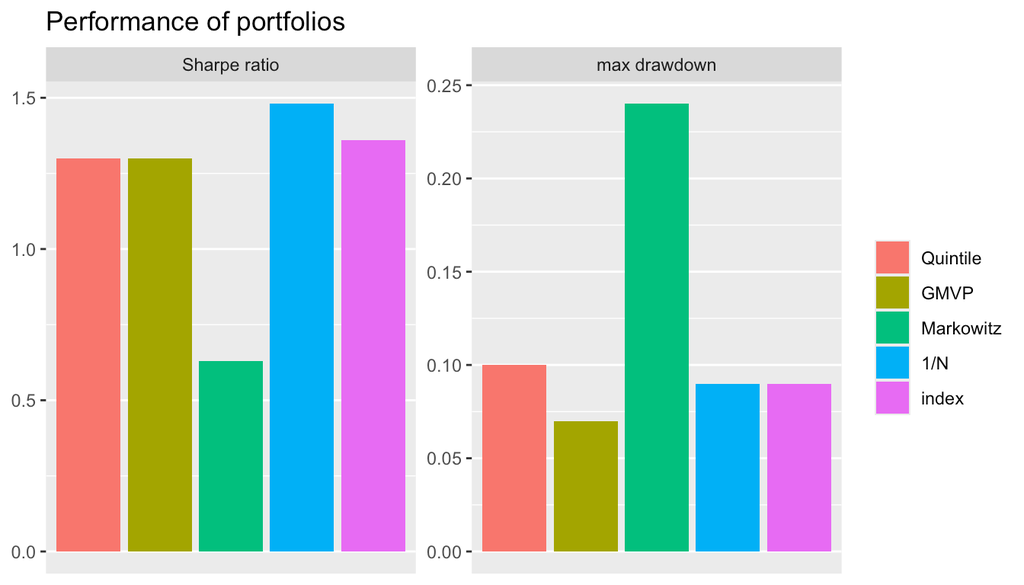

```r
summaryBarPlot(res_sum, measures = c("Sharpe ratio", "max drawdown"))
```

- BoxPlot (probably the best way to properly compare the performance of different portfolios with a single performance measure):

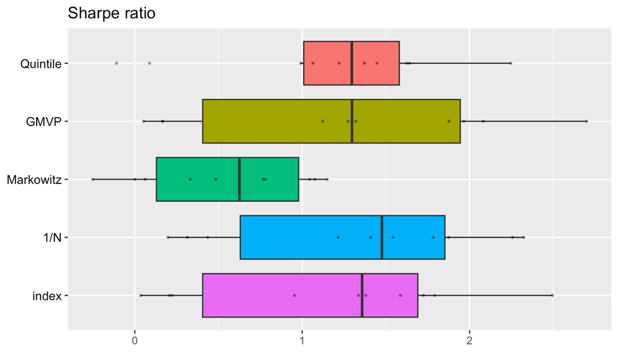

```r
backtestBoxPlot(bt, measure = "Sharpe ratio")
```

- Cumulative return or wealth plot of a single backtest:

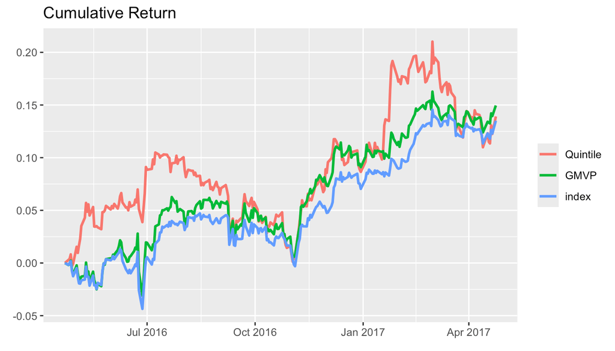

```r
backtestChartCumReturn(bt, c("Quintile", "GMVP", "index"))
```

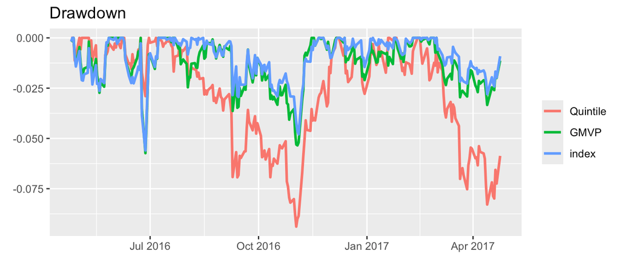

```r
backtestChartDrawdown(bt, c("Quintile", "GMVP", "index"))
```

- Portfolio allocation evolution of a particular portfolio over a particular backtest:

```r
# for better illustration, let's use only the first 5 stocks
dataset10_5stocks <- lapply(dataset10,
                            function(x) {x$adjusted <- x$adjusted[, 1:5]; return(x)})
# backtest
bt <- portfolioBacktest(list("GMVP" = GMVP_portfolio_fun), dataset10_5stocks,
                        rebalance_every = 20)
```

```
#> Backtesting 1 portfolios over 10 datasets (periodicity = daily data)...
```

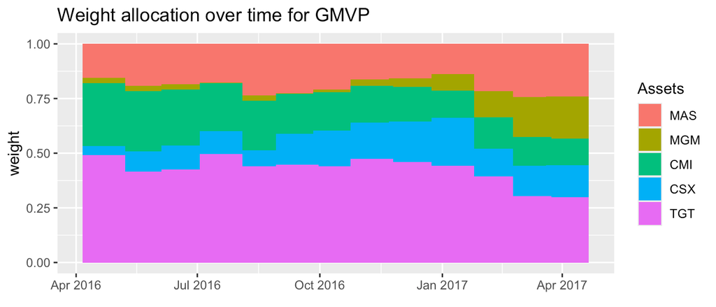

```r
# chart
backtestChartStackedBar(bt, "GMVP", legend = TRUE)
```

# Advanced Usage

## Transaction costs

By default, transaction costs are not included in the backtesting, but the user can easily specify the cost to be used for a more realistic backtesting:

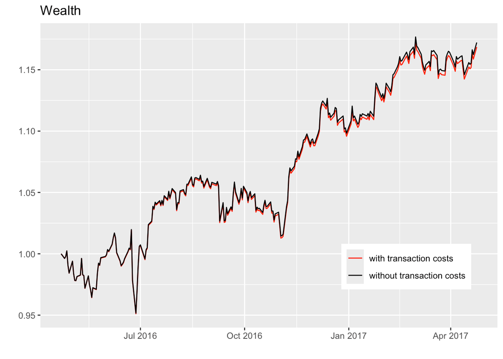

```r
library(ggfortify)

# backtest without transaction costs
bt <- portfolioBacktest(my_portfolio, dataset10)

# backtest with costs of 15 bps
bt_tc <- portfolioBacktest(my_portfolio, dataset10,
                           cost = list(buy = 15e-4, sell = 15e-4))

# plot wealth time series
wealth <- cbind(bt$fun1$`dataset 1`$wealth, bt_tc$fun1$`dataset 1`$wealth)
colnames(wealth) <- c("without transaction costs", "with transaction costs")

autoplot(wealth, facets = FALSE, main = "Wealth") +
  theme(legend.title = element_blank()) +
  theme(legend.position = c(0.8, 0.2)) +
  scale_color_manual(values = c("red", "black"))
```

## Incorporating benchmarks

When performing the backtest of the designed portfolio functions, one may want to incorporate some benchmarks. The package currently suppports two benchmarks: `1/N` portfolio and `index` of the market. (Note that to incorporate the `index` benchmark each dataset needs to contain one `xts` object named `index`.) Once can easily choose the benchmarks by passing the corresponding value to argument `benchmark`:

```r
bt <- portfolioBacktest(portfolios, dataset10, benchmark = c("1/N", "index"))
```

```
#> Backtesting 3 portfolios over 10 datasets (periodicity = daily data)...
#> Backtesting benchmarks...
```

```r
names(bt)
```

```
#> [1] "Quintile"  "GMVP"      "Markowitz" "1/N"       "index"
```

## Parameter tuning in portfolio functions

Portfolio functions usually contain some parameters that can be tuned. One can manually generate different versions of such portfolio functions with a variety of parameters. Fortunately, the function `genRandomFuns()` helps with this task by automatically generating different versions of the portfolios with randomly chosen paramaters:

```r
# define a portfolio with parameters "lookback", "quintile", and "average_type"
quintile_portfolio_fun <- function(dataset, ...) {
  prices <- tail(dataset$adjusted, lookback)
  X <- diff(log(prices))[-1]
  mu <- switch(average_type,
               "mean" = colMeans(X),
               "median" = apply(X, MARGIN = 2, FUN = median))
  idx <- sort(mu, decreasing = TRUE, index.return = TRUE)$ix
  w <- rep(0, ncol(X))
  w[idx[1:ceiling(quintile*ncol(X))]] <- 1/ceiling(quintile*ncol(X))
  return(w)
}

# then automatically generate multiple versions with randomly chosen parameters
portfolio_list <- genRandomFuns(portfolio_fun = quintile_portfolio_fun,
                                params_grid = list(lookback = c(100, 120, 140, 160),
                                                   quintile = 1:5 / 10,
                                                   average_type = c("mean", "median")),
                                name = "Quintile",
                                N_funs = 40)
```

```
#> Generating 40 functions out of a total of 40 possible combinations.
```

```r
names(portfolio_list[1:5])
```

```
#> [1] "Quintile (lookback=140, quintile=0.5, average_type=mean)"
#> [2] "Quintile (lookback=160, quintile=0.1, average_type=mean)"
#> [3] "Quintile (lookback=120, quintile=0.5, average_type=mean)"
#> [4] "Quintile (lookback=120, quintile=0.1, average_type=median)"
#> [5] "Quintile (lookback=120, quintile=0.4, average_type=median)"
```

```r
portfolio_list[[1]]
```

```
#> function(dataset, ...) {
#>   prices <- tail(dataset$adjusted, lookback)
#>   X <- diff(log(prices))[-1]
#>   mu <- switch(average_type,
#>                "mean" = colMeans(X),
#>                "median" = apply(X, MARGIN = 2, FUN = median))
#>   idx <- sort(mu, decreasing = TRUE, index.return = TRUE)$ix
#>   w <- rep(0, ncol(X))
#>   w[idx[1:ceiling(quintile*ncol(X))]] <- 1/ceiling(quintile*ncol(X))
#>   return(w)
#> }
#> <environment: 0x7fe974c77290>
#> attr(,"params")
#> attr(,"params")$lookback
#> [1] 140
#>
#> attr(,"params")$quintile
#> [1] 0.5
#>
#> attr(,"params")$average_type
#> [1] "mean"
```

Now we can proceed with the backtesting:

```r
bt <- portfolioBacktest(portfolio_list, dataset10)
```

```
#> Backtesting 40 portfolios over 10 datasets (periodicity = daily data)...
```

Finally we can observe the performance for all combinations of parameters backtested:

```
#> Parameter grid:
#>    lookback = c(100, 120, 140, 160)
#>    quintile = c(0.1, 0.2, 0.3, 0.4, 0.5)
#>    average_type = c("mean", "median")
#>
#> Parameter types: 0 fixed, 2 variable numeric, and 1 variable non-numeric.
```

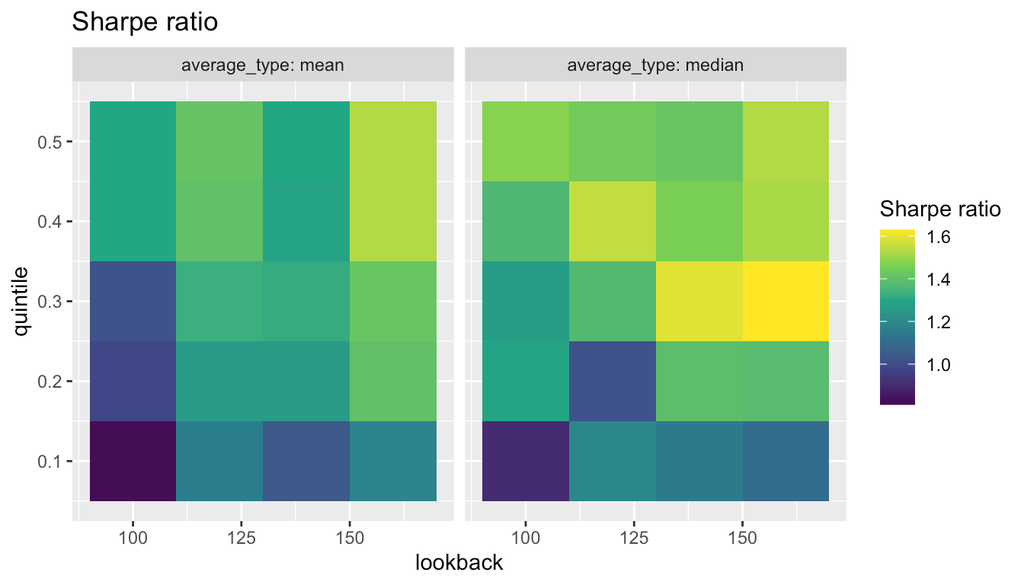

```r
plotPerformanceVsParams(bt)
```

In this case, we can conclude that the best combination is to use the median of the past 160 days and using the 0.3 top quintile. Extreme caution has to be taken when tuning hyper-parameter of strategies due to the danger of overfitting (Bailey et al. 2016).

## Progress bar

In order to monitor the backtest progress, one can choose to turn on a progress bar by setting the argument `show_progress_bar`:

```r
bt <- portfolioBacktest(portfolios, dataset10, show_progress_bar = TRUE)
```

## Parallel backtesting

The backtesting typically incurs in a very heavy computational load when the number of portfolios or datasets is large (also depending on the computational cost of each portfolio function). The package contains support for parallel computational mode. Users can choose to evaluate different portfolio functions in parallel or, in a more fine-grained way, to evaluate multiple datasets in parallel for each function:

```r
portfun <- Markowitz_portfolio_fun

# parallel = 2 for functions
system.time(
  bt_noparallel <- portfolioBacktest(list(portfun, portfun), dataset10)
  )
```

```
#> Backtesting 2 portfolios over 10 datasets (periodicity = daily data)...
#>    user  system elapsed
#>  63.594   0.730  65.451
```

```r
system.time(
  bt_parallel_funs <- portfolioBacktest(list(portfun, portfun), dataset10,
                                        paral_portfolios = 2)
  )
```

```
#> Backtesting 2 portfolios over 10 datasets (periodicity = daily data)...
#>    user  system elapsed
#>   0.689   0.201  38.423
```

```r
# parallel = 5 for datasets
system.time(
  bt_noparallel <- portfolioBacktest(portfun, dataset10)
  )
```

```
#> Backtesting 1 portfolios over 10 datasets (periodicity = daily data)...
#>    user  system elapsed
#>  31.136   0.300  31.862
```

```r
system.time(
  bt_parallel_datasets <- portfolioBacktest(portfun, dataset10,
                                            paral_datasets = 5)
  )
```

```
#> Backtesting 1 portfolios over 10 datasets (periodicity = daily data)...
#>    user  system elapsed
#>   1.538   0.377  21.089
```

It is obvious that the evaluation time for backtesting has been significantly reduced. Note that the parallel evaluation elapsed time will not be exactly equal to the original time divided by parallel cores because starting new R sessions also takes extra time. Besides, the two parallel modes can be simultaneous used.

Note that an unexpected error might be thrown out when running a parallel backtest through [RStudio in macOS](https://github.com/rstudio/rstudio/issues/6692). If that happens, one can check the default parallel setting via:

```r
parallel:::getClusterOption("setup_strategy")
```

If `"parallel"` is returned, one can set the option `setup_strategy` to `"sequential"`:

```r
parallel:::setDefaultClusterOptions(setup_strategy = "sequential")
```

The problem may be fixed. However, the “sequential” strategy might be less efficient than the “parallel” strategy.

## Initialization for each backtest

In some cases, one may want to do initialize some variable at the beginning of each backtest and be able to access those variables during the rolling-window process. At the moment, the package does not support this initialization. However, there is a hack that can be used for the time being (via the use of non-recommended global variables):

```r
allocation <- 0  # initialize global variable to 0

test_portfolio <- function(dataset, ...) {
  N <- ncol(dataset$adjusted)

  w <- rep(allocation, N)
  allocation <<- 1/N  # after first time it becomes 1/N

  return(w)
}


bt <- portfolioBacktest(list("test" = test_portfolio),
                        dataset_list = dataset10[1:2],
                        lookback = 100, optimize_every = 200,
                        paral_datasets = 2)  # <--- this argument is necessary (has to be > 1)

# sanity check
bt$test$`dataset 1`$w_optimized[, 1:2]
bt$test$`dataset 2`$w_optimized[, 1:2]
```

Note that for this hack to work, one needs `paral_datasets > 1`.

## Tracing where execution errors happen

Execution errors during backtesting may happen unexpectedly when executing the different portfolio functions. Nevertheless, such errors are properly catched and bypassed by the backtesting function `portfolioBacktest()` so that the execution of the overall backtesting is not stopped. For debugging purposes, to help the user trace where and when the execution errors happen, the result of the backtesting contains all the necessary information about the errors, including the call stack when a execution error happens. Such information is given as the attribute `error_stack` of the returned `error_message`.

For example, let’s define a portfolio function that will throw a error:

```r
sub_function2 <- function(x) {
  "a" + x  # an error will happen here
}

sub_function1 <- function(x) {
  return(sub_function2(x))
}

wrong_portfolio_fun <- function(data, ...) {
  N <- ncol(data$adjusted)
  uni_port <- rep(1/N, N)
  return(sub_function1(uni_port))
}
```

Now, let’s pass the above portfolio function to `portfolioBacktest()` and see how to check the error trace:

```r
bt <- portfolioBacktest(wrong_portfolio_fun, dataset10)
```

```
#> Backtesting 1 portfolios over 10 datasets (periodicity = daily data)...
```

```r
res <- backtestSelector(bt, portfolio_index = 1)

# information of 1st error
error1 <- res$error_message[[1]]
str(error1)
```

```
#>  chr "non-numeric argument to binary operator"
#>  - attr(*, "error_stack")=List of 2
#>   ..$ at   : chr "\"a\" + x"
#>   ..$ stack: chr "sub_function1(uni_port)\nsub_function2(x)"
```

```r
# the exact location of error happening
cat(attr(error1, "error_stack")$at)
```

```
#> "a" + x
```

```r
# the call stack of error happening
cat(attr(error1, "error_stack")$stack)
```

```
#> sub_function1(uni_port)
#> sub_function2(x)
```

## Backtesting over files: usage for grading students

In some situations, one may have to backtest portfolios from different sources stored in different files, e.g., students in a porftolio design course (in fact, this package was originally developed to assess students in the course “Portfolio Optimization with R” from the [MSc in Financial Mathematics (MAFM)](https://mafm.hkust.edu.hk/)). In such cases, the different portfolios may have conflicting dependencies and loading all of them into the environment may not be a reasonable approach. The package adds support for backtesting portfolios given in individual files in a folder in a way that each is executed in a clean environment without affecting each other. It suffices to write each portfolio function into an R script (with unique filename) containing the portfolio function named exactly `portfolio_fun()` as well as any other auxiliary functions that it may require (needless to say that the required packages should be loaded in that script with `library()`). All theses files should be put into a file folder, whose path will be passed to the function `portfolioBacktest()` with the argument `folder_path`.

If an instructor wants to evaluate students of a course in their portfolio design, this can be easily done by asking each student to submit an R script with a unique filename like `STUDENTNUMBER.R`. For example, suppose we have three files in the folder `portfolio_files` named `0001.R`, `0002.R`, and `0003.R`. Then:

```r
bt_all_students <- portfolioBacktest(folder_path = "portfolio_files",
                                     source_to_local = FALSE,
                                     dataset_list = dataset10)
```

```
#> Backtesting 3 portfolios over 10 datasets (periodicity = daily data)...
```

```r
names(bt_all_students)
```

```
#> [1] "0001" "0002" "0003"
```

Note that if the package `CVXR` is used in some of the files, it may not work depending on the version. A temporary workaround is to set the argument `source_to_local = FALSE` in `portfolioBacktest()` (the side effect is that the objects from the file will be loaded in the global environment).

## Leaderboard of portfolios with user-defined ranking

Now we can rank the different portfolios/students based on a weighted combination of the rank percentiles (termed scores) of the performance measures:

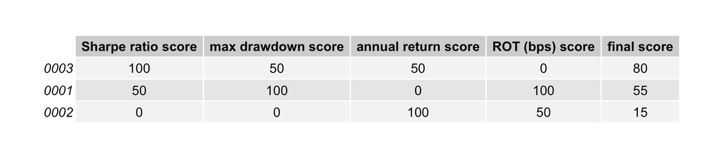

```r
leaderboard <- backtestLeaderboard(bt_all_students,
                                   weights = list("Sharpe ratio"  = 7,
                                                  "max drawdown"  = 1,
                                                  "annual return" = 1,
                                                  "ROT (bps)"     = 1))

# show leaderboard
library(gridExtra)
grid.table(leaderboard$leaderboard_scores)
```

## Example of a script file to be submitted by a student

Consider the student with id number 666. Then the script file should be named `666.R` and should contain the portfolio function called exactly `portfolio_fun()` as well as any other auxiliary functions that it may require (and any required package loading with `library()`):

```r
library(CVXR)

auxiliary_function <- function(x) {
  # here whatever code
}

portfolio_fun <- function(data, ...) {
  X <- as.matrix(diff(log(data$adjusted))[-1])  # compute log returns
  mu <- colMeans(X)  # compute mean vector
  Sigma <- cov(X)  # compute the SCM
  # design mean-variance portfolio
  w <- Variable(nrow(Sigma))
  prob <- Problem(Maximize(t(mu) %*% w - 0.5*quad_form(w, Sigma)),
                  constraints = list(w >= 0, sum(w) == 1))
  result <- solve(prob)
  return(as.vector(result$getValue(w)))
}
```

# Appendix

## Performance criteria

The performance criteria currently considered by default in the package are:

- **annual return**: the (geometric) [annualized return](https://en.wikipedia.org/wiki/Rate_of_return);
- **annual volatility**: the annualized standard deviation of returns;
- **max drawdown**: the maximum drawdown is defined as the maximum loss from a peak to a trough of a portfolio;
- **Sharpe ratio**: the [annualized Sharpe ratio](https://en.wikipedia.org/wiki/Sharpe_ratio), the ratio between the (geometric) annualized return and the annualized standard deviation;
- **Sterling ratio**: the return over average drawdown, see [here](https://en.wikipedia.org/wiki/Sterling_ratio) for complete definition. In the package, we use
  $$\text{Sterling ratio} = \frac{\text{annualized return}}{\text{max
  drawdown}};$$
- **Omega ratio**: the probability weighted ratio of gains over losses for some threshold return target, see [here](https://en.wikipedia.org/wiki/Omega_ratio) for complete definition. The ratio is calculated as:
  $$\Omega(r) = \frac{\int_{r}^{\infty} (1-F(x))dx}{\int_{-\infty}^{r}
  F(x)dx};$$
  In the package, we use $\Omega(0)$, which is also known as Gain-Loss-Ratio.
- **ROT bps**: Return over Turnover (ROT) defined as the sum of cummulative return over the sum of turnover.

A detailed treatment of portfolio performance measures is given in (Palomar 2025, Ch. 6). One can easily add new performance measures with the function `add_performance()`.

# References

Bailey, D., Borwein, J., de Prado, M.L.: [Stock portfolio design and backtest overfitting](https://www.ssrn.com/abstract=2739335). Journal of Investment Management. 15, 1–13 (2016)

Luo, Y., Alvarez, M., Wang, S., Jussa, J., Wang, A., Rohal, G.: Seven sins of quantitative investing. White paper, Deutsche Bank Markets Research. (2014)

Palomar, D.P.: [Portfolio optimization: Theory and application](https://portfoliooptimizationbook.com). Cambridge University Press (2025)